# Experiment

06 sep 2018

## Content

## Experiment

## Heads

[figure not shown]

bit.ly/2j54A2U

## Emperical Cycle

- **Observation** Patiënt is showing post traumatic symptoms
- **Induction** Intherapy works
- **Deduction** \(H_0\): P: fair coin → C: patiënt is balanced
- **Deduction** \(H_A\): P: Unfair coin → C: patiënt is unbalanced
- **Deduction** \(H_A\): P: data \(\neq\) EV → C: is unbalanced
- **Testing** Choose \(\alpha\) and Power
- **Evaluation** Make a decision

## Nul distribution

Let’s analyse the null distribution of the results.

[interactive chart not shown]

[Google sheet](https://docs.google.com/spreadsheets/d/150iSLUXqZbsetzDMjYlY5CAcjIzTanTm2tOFfn_ConA/edit?usp=sharing)

## Binomial distribution

\[ {n\choose k}p^k(1-p)^{n-k} \\ {n\choose k} = \frac{n!}{k!(n-k)!} \]

With values:

```r
n = 10   # Sample size
k = 0:10 # Discrete probability space
p = .5   # Probability of head
```

## Probabilities

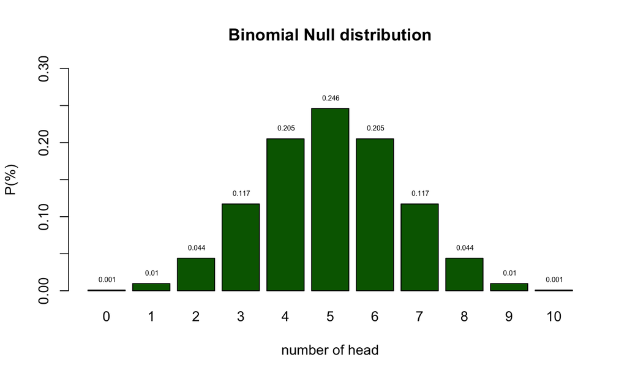

## Testing

I landed 2 times head. Can we conclude that the therapy worked?

- As you can see from the distribution of healthy coins, we cannot conclude that by definition.
- What we can do is indicate how rare 2 is in a healthy population.
- We can see that a percentage of 5% is very rare.

## Testing

- Based on the null distribution we can see that the expected value (EV is 5.)
- We can now define the \(H_0\) hypothesis: \(H_0 = 5\)
- What is the alternative hypothesis?
- The alternative hypothesis describes a situation where the therapy worked.
- We could say that the alternative hypothesis is not 5.
  - \(H_A \ne 5\)
- We could also formulate our \(H_0\) and \(H_A\) more abstract:
  - \(H_0:\) the patient is balenced
  - \(H_A:\) the patient is unbalenced
- What criterium should we use to conclude that one would be unbalenced?
- In the social sciences this \(\alpha\) criteria is often 5%.
- I tossed 2 times head. That is more frequent than 5%.
- Therefore, we conclude that our patient is probably healthy but we can never be sure.
- My coin could still be part of the unbalenced population.

## Alternative Distribution

But we have no clue of what this distribution could look like.

For now let’s assume the probability of landing heads for my coin is .25

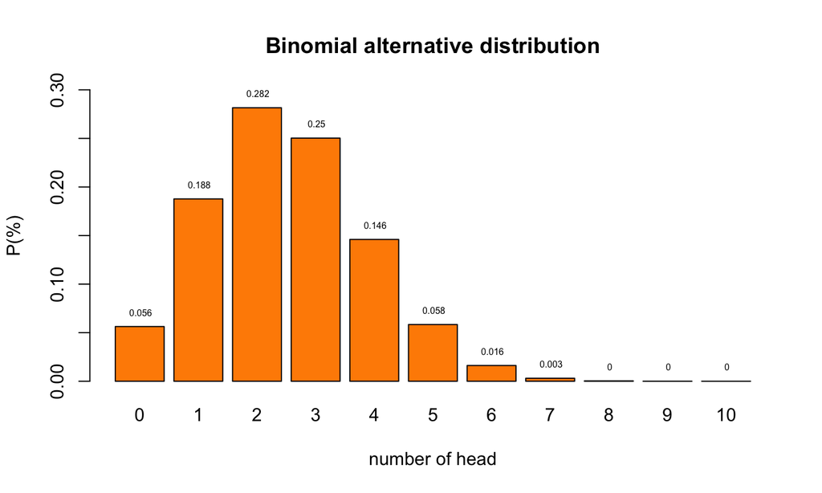

## \(H_0\) and \(H_A\) distribution

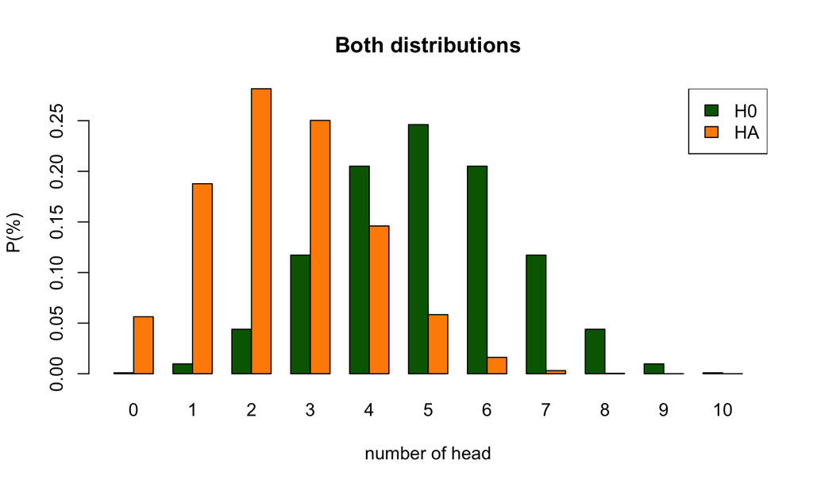

```
Not reject H0
```

## Power and more

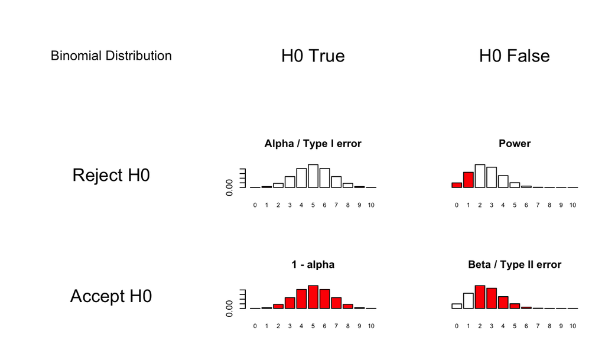

## End

- [@shklinkenberg](https://twitter.com/shklinkenberg)
- [Klinkenberg](https://www.linkedin.com/in/sharonklinkenberg/)
- ln.AvU@grebneknilK.S
- ShKlinkenberg